[figure not shown]

03-05-2024 >eR-BioStat

**Foundations for inference using R**

Ziv Shkedy and Thi Huyen Nguyen based on Chapter 4 in the book of Julie Vu and Dave Harrington *Introductory Statistics for the Life and Biomedical Sciences* (https://www.openintro.org/book/biostat/)

```r
## load/install libraries
.libPaths(c("./Rpackages",.libPaths()))
library(knitr)
library(tidyverse)
library(deSolve)
library(minpack.lm)
library(ggpubr)
library(readxl)
library(gamlss)
library(data.table)
library(grid)
library(png)
library(nlme)
library(gridExtra)
library(mvtnorm)
library(e1071)
library(lattice)
library(ggplot2)
library(dslabs)
library(NHANES)
library(plyr)
library(dplyr)
library(nasaweather)
library(ggplot2)
library(gganimate)
library(av)
library(gifski)
library(foreach)
library("DAAG")
library(DT)
library(TeachingDemos)
library(gridExtra)
```

# 1. Variability in estimates

## A point estimate for the population parameter

A natural way to estimate features of the population, such as the population mean weight,is to use the corresponding summary statistic calculated from the sample. For example, the sample mean $\bar{x}$ is a point parameter estimate for the population (unknown) mean $\mu$ and the sample variance $s^{2}$ is a point parameter estimate for the population variance $\sigma^{2}$.

## Example: the wind speed in the airquality dataset

### Data and point estimates

The `airquality` dataset gives information about 153 daily air quality measurements in New York, May to September 1973.

```r
dim(airquality)
```

```
## [1] 153   6
```

```r
head(airquality)
```

```
##   Ozone Solar.R Wind Temp Month Day
## 1    41     190  7.4   67     5   1
## 2    36     118  8.0   72     5   2
## 3    12     149 12.6   74     5   3
## 4    18     313 11.5   62     5   4
## 5    NA      NA 14.3   56     5   5
## 6    28      NA 14.9   66     5   6
```

The variable `Wind` is the average wind speed in miles per hour at 0700 and 1000 hours at LaGuardia Airport. The mean wind speed is $\hat{\mu}=\bar{x}=9.95$ and the sample standard deviation is $\hat{\sigma}=s=3.52$. This sample mean is a point estimate of the population mean. If a different random sample of 153 days were taken the new sample mean would likely be different as a result of sampling variation. Note that while estimates generally vary from one sample to another, the population mean is a fixed value.

```r
wind<-airquality$Wind
mean(wind)
```

```
## [1] 9.957516
```

```r
sd(wind)
```

```
## [1] 3.523001
```

### Visualization

```r
#ggplot(airquality, aes(x = Wind)) +
#  geom_histogram(fill = "skyblue", color = "black")+
#  ylab("Frequency")
```

Figure 1 and 2 show a histogram and boxplot of the data. Both Figures indicate a slightly skewed distribution to the right.

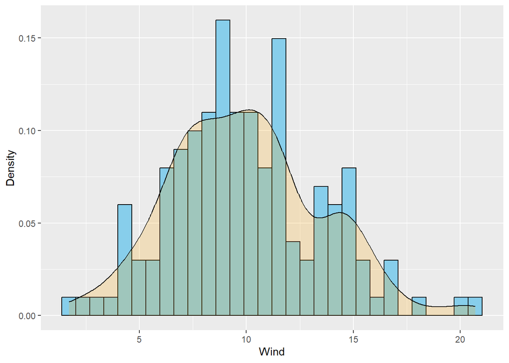

Figure 1: Histogram with density plot of wind speed.

```r
ggplot(airquality, aes(x = Wind)) +
  geom_histogram(aes(y = ..density..), fill = "skyblue", color = "black") +
  geom_density(alpha = 0.2, fill = "orange")+
  ylab("Density")
```

```r
#ggplot(airquality, aes(x = c(1:length(airquality$Wind)), y = Wind)) +
#  geom_point(position = position_jitter(height = 0.05), color = "blue")
#  xlab("")
```

```r
#ggplot(airquality, aes(x = "", y = Wind)) +
#  geom_boxplot(fill = "skyblue", color = "black")+
#  xlab("")
```

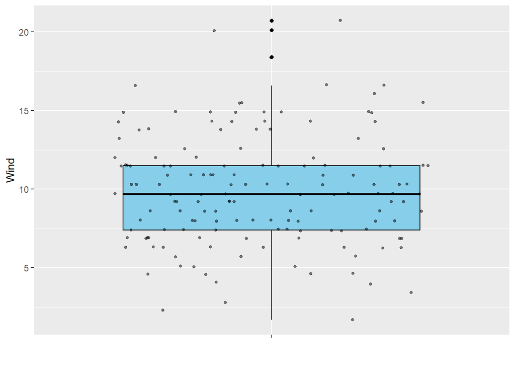

Figure 2: Box plot of wind speed.

```r
ggplot(airquality, aes(x = "", y = Wind)) +
  geom_boxplot(fill = "skyblue", color = "black")+
  geom_jitter(aes(x = "", y = Wind), color = "black", size = 1, alpha = 0.5)+
  xlab("")
```

```r
#ggplot(airquality, aes(x = "", y = Wind)) +
#  geom_violin(fill = "lightblue")+
#  xlab("")
```

```r
#ggplot(airquality, aes(x = "", y = Wind)) +
#  geom_violin(fill = "lightblue")+
#  geom_jitter(aes(x = "", y = Wind), color = "black", size = 1, alpha = #0.5)+
#  xlab("")
```

## The variability of the sample mean

```r
ni<-seq(from=1,to=1000,by=1)
m.x<-c(1:length(ni))
for(i in 1:length(ni))
{
xsample<-rnorm(ni[i],0,1)
m.x[i]<-mean(xsample)
}
```

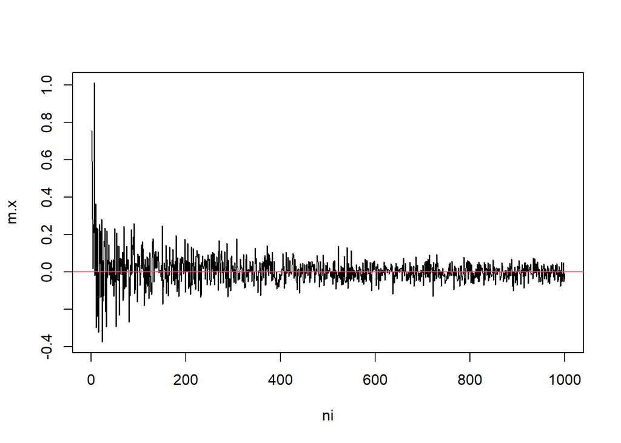

Figure 3: Sample mean of a random sample from $N(0,1)$.

```r
plot(ni,m.x,type="l")
abline(0,0,col=2)
```

## The sampling distribution for the mean

```r
ni<-50
m.x<-c(1:1000)
for(i in 1:1000)
{
xsample<-rnorm(ni,0,1)
m.x[i]<-mean(xsample)
}
```

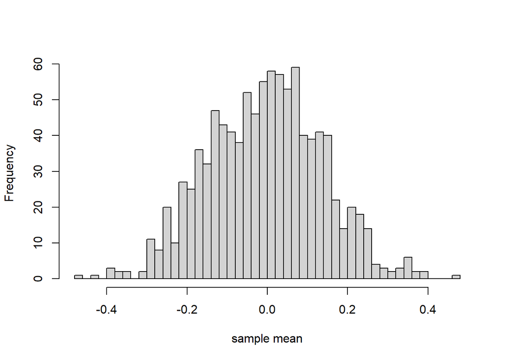

Figure 4: A histogram of 1000 sample means from $N(0,1)$, n = 50.

```r
par(mfrow=c(1,1))
#plot(c(1:1000),m.x,type="l",xlab="sample",ylab="sample mean")
#abline(0,0,col=2)
hist(m.x,nclass=50,main=" ",xlab="sample mean")
```

## the Central Limit Theorem

Since the complete sampling distribution consists of means for all possible samples of size 50, drawing a much larger number of samples provides a more accurate view of the distribution; the left panel of Figure 5 shows the distribution calculated from 100,000 sample means. A normal probability plot of these sample means is shown in the right panel of Figure 5. All of the points closely fall around a straight line, implying that the distribution of sample means is nearly normal (see Section 3.3). This result follows from the Central Limit Theorem.

```r
ni<-50
m.x<-c(1:100000)
for(i in 1:100000)
{
xsample<-rnorm(ni,0,1)
m.x[i]<-mean(xsample)
}
```

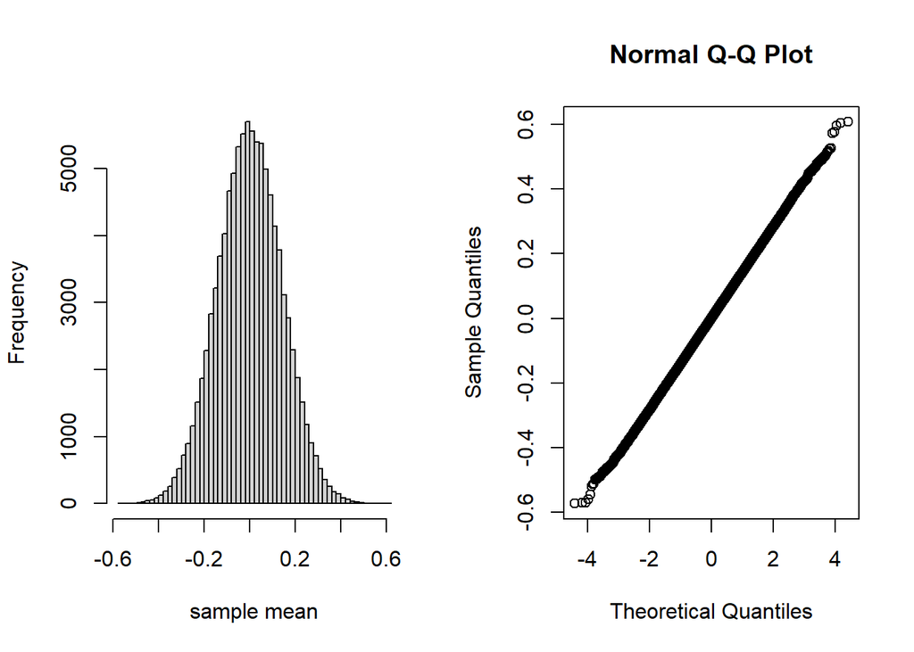

Figure 5: The central limit theorem. A histogram of 100000 sample means from $N(0,1)$ (left panel) and a normal probability plot (right panel), n = 50.

```r
par(mfrow=c(1,2))
hist(m.x,nclass=50,main=" ",xlab="sample mean")
qqnorm(m.x)
```

The sampling distribution for the mean is unimodal and symmetric around the mean of the random variable $\bar{X}$. Statistical theory can be used to show that the mean of the sampling distribution for $\bar{X}$ is exactly equal to the population mean $\mu$. However, in almost any study, conclusions about a population parameter must be drawn from the data collected from a single sample. The sampling distribution of $\bar{X}$ is a theoretical concept, since obtaining repeated samples by conducting a study many times is not possible. In other words, it is not feasible to calculate the population mean $\mu$ by finding the mean of the sampling distribution for $\bar{X}$.

# 2. Standard error of the mean

## Estimation of the variability of $\bar{X}$

The standard error (SE) of the sample mean measures the sample-to-sample variability of $\bar{X}$ , the extent to which values of the repeated samplemeans oscillate around the populationmean. The error theoretical standard error of the sample mean is calculated by dividing the population standard deviation ($\sigma_{X}$) by the square root of the sample size $n$. Since the population standard deviation _ is typically unknown, the sample standard deviation s is often used in the definition of a standard error; $s$ is a reasonably good estimate of $\sigma_{X}$. If $\bar{X}$ represents the sample mean weight, its standard error (denoted by SE) is given by

$$SE_{\bar{X}}=\frac{s}{\sqrt{n}}$$
.

This estimate tends to be sufficiently good when the sample size is at least 30 and the population distribution is not strongly skewed. In the case of skewed distributions, a larger sample size is necessary.

## Example: $SE_(\bar{X})$ for samples from $N(0,1)$

```r
ni1<-50
ni2<-100
m.x1<-m.x2<-c(1:100000)
for(i in 1:100000)
{
xsample1<-rnorm(ni1,0,1)
xsample2<-rnorm(ni2,0,1)
m.x1[i]<-mean(xsample1)
m.x2[i]<-mean(xsample2)
}
```

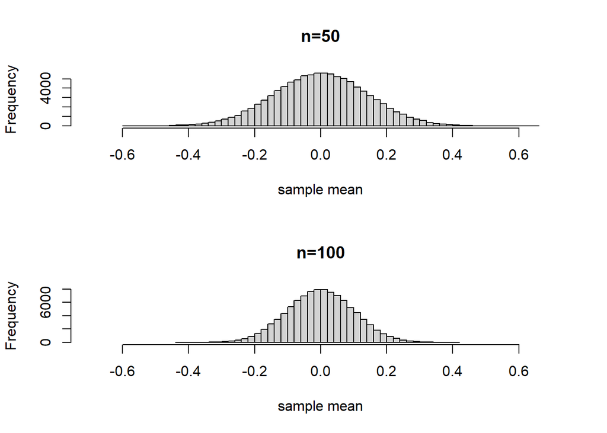

Figure 6: Histograms of 100000 sample means from $N(0,1)$, n = 50,100.

```r
par(mfrow=c(2,1))
hist(m.x1,nclass=50,main="n=50",xlab="sample mean",xlim=c(-0.7,0.7))
hist(m.x2,nclass=50,main="n=100",xlab="sample mean",xlim=c(-0.7,0.7))
```

# 3. Confidence intervals

## Interval estimates for a population parameter

While a point estimate consists of a single value, an interval estimate provides a plausible range of values for a parameter. When estimating a population mean $\mu$, a confidence interval for $\mu$ has the general form
$$(\bar{x} -m; \bar{x} +m) = \bar{x} \pm m ,$$
where $m$ is the margin of error. Intervals that have this form are called two-sided confidence intervals because they provide both lower and upper bounds, $\bar{x} - m$ and $\bar{x} +m$ , respectively.

## Confidence interval based on a Normal distribution

The standard error of the sample mean is the standard deviation of its distribution; additionally, the distribution of sample means is nearly normal and centered at $\mu$. Under the normal model, the sample mean $\bar{x}$ will be within 1.96 standard errors (i.e., standard deviations) of the population mean $\mu$ approximately 95% of the time. Thus, if an interval is constructed that spans 1.96 standard errors from the point estimate in either direction, a data analyst can be 95% confident that the interval
$$\bar{x} \pm 1.96 \times SE$$
contains the population mean. As shown in Figure 7, $-1.96$ and $1.96$ are the $2.5\%$ and $97.5\%$ quantiles of the standard normal distribution $N(0,1)$.

```r
x<-seq(from=-3,to=3,length=1000)
dx<-dnorm(x,0,1)
qx<-qnorm(0.025,0,1)
qx
```

```
## [1] -1.959964
```

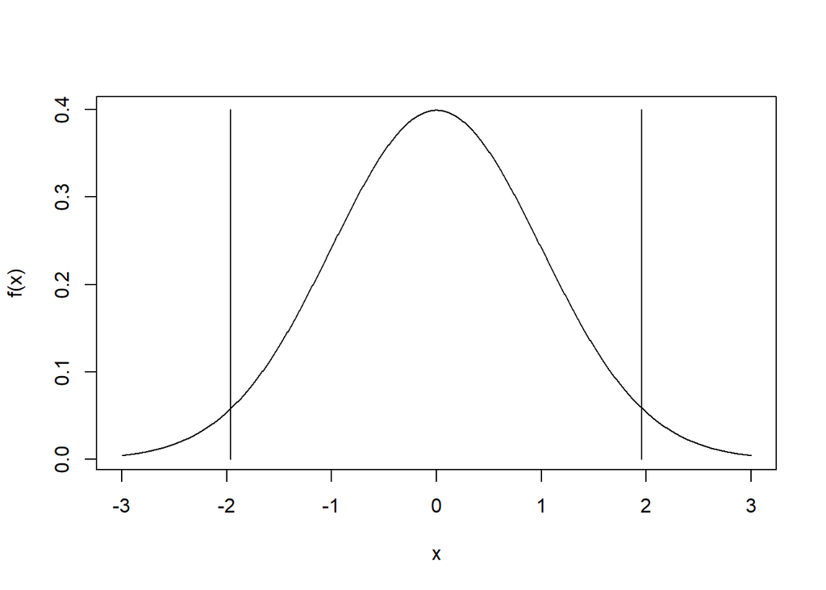

Figure 7: The $2.5$ ($Z_{0.025}$) and $97.5$ ($Z_{0.975}$) quantiles of $N(0,1)$.

```r
plot(x,dx,type="l",ylab="f(x)")
lines(c(qx,qx),c(0,0.4))
lines(-c(qx,qx),c(0,0.4))
```

## Coverage rate

The value $95\%$ is an approximation, accurate when the sampling distribution for the sample mean is close to a normal distribution. This assumption holds when the sample size is sufficiently large. The phrase “$95\%$ confident” has a subtle interpretation: if many samples were drawn from a population, and a confidence interval is calculated from each one using Equation 4.2, about $95\%$ of those intervals would contain the population mean$\mu$. Figure 8 illustrates this process with 100 confidence intervals obtained for 100 samples of size $n=25$ taken from $N(0,1)$.

```r
ni1<-25
B<-100
m.x1<-sd.x<-UL<-LL<-SE<-c(1:B)
for(i in 1:B)
{
xsample<-rnorm(ni1,0,1)
m.x1[i]<-mean(xsample)
sd.x[i]<-sqrt(var(xsample))
SE[i]<-sd.x[i]/sqrt(ni1)
LL[i]<-m.x1[i]-1.96*SE[i]
UL[i]<-m.x1[i]+1.96*SE[i]
}
```

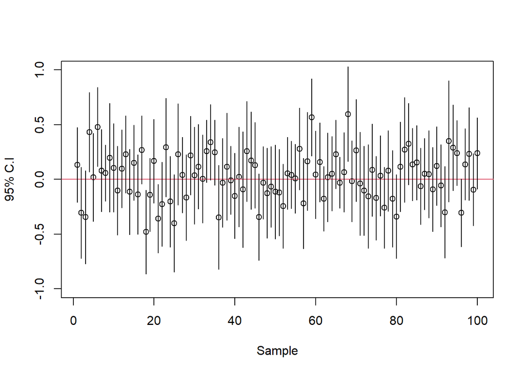

Figure 8: Confidence intervals for 100 samples (n=25) from $N(0,1)$.

```r
plot(c(1:B),m.x1,ylim=c(-1,1),xlab="Sample",ylab="95% C.I")
abline(0,0,col=2)
for(i in 1:B)
{
lines(c(i,i),c(LL[i],UL[i]))
}
```

## Example: a $95\%$ confidence interval for the wind speed

### calculation of the lower and upper limits

Figure 9 shows the histogram for the average wind speed in miles per hour at 0700 and 1000 hours at LaGuardia Airport in 1973. The mean wind speed is $\hat{\mu}=\bar{x}=9.95$ and the sample standard deviation is $\hat{\sigma}=s=3.52$.

```r
wind<-airquality$Wind
M.wind<-mean(wind)
SD.wind<-sqrt(var(wind))
M.wind
```

```
## [1] 9.957516
```

```r
SD.wind
```

```
## [1] 3.523001
```

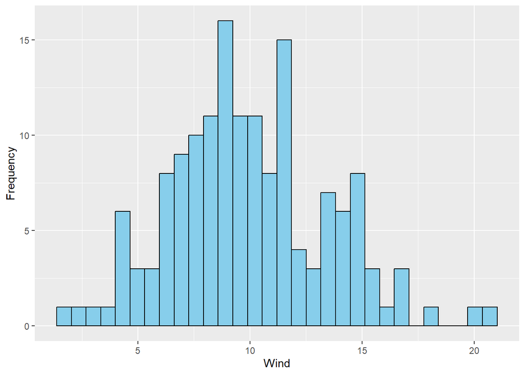

Figure 9: Histogram of wind speed.

```r
ggplot(airquality, aes(x = Wind)) +
  geom_histogram(fill = "skyblue", color = "black")+
  ylab("Frequency")
```

The standard error for the sample mean is equal to 0.2848,

$$\frac{3.52}{\sqrt{153}}=0.2848$$
.

```r
n<-length(wind)
SE<-SD.wind/sqrt(n)
SE
```

```
## [1] 0.2848178
```

A $95\%$ confidence interval for the wind speed is given by

$$\bar{x}_{wind} \pm 1.96 \times SE = 9.95 \pm 1.96 \times 0.2848$$
,

```r
LL<-M.wind-1.96*SE
UL<-M.wind+1.96*SE
c(LL,UL)
```

```
## [1]  9.399273 10.515759
```

### Visualization

Let us look at Figure 10 which shows the histogram of the average wind per day and, the sample mean and the upper and lower limits of the $95%$ confidence intervals (red lines) and sample mean (green line). Figure 11 shows the data with the $95\%$ confidence interval.

```r
wind<-airquality$Wind
M.wind<-mean(wind)
SD.wind<-sqrt(var(wind))
M.wind
```

```
## [1] 9.957516
```

```r
SD.wind
```

```
## [1] 3.523001
```

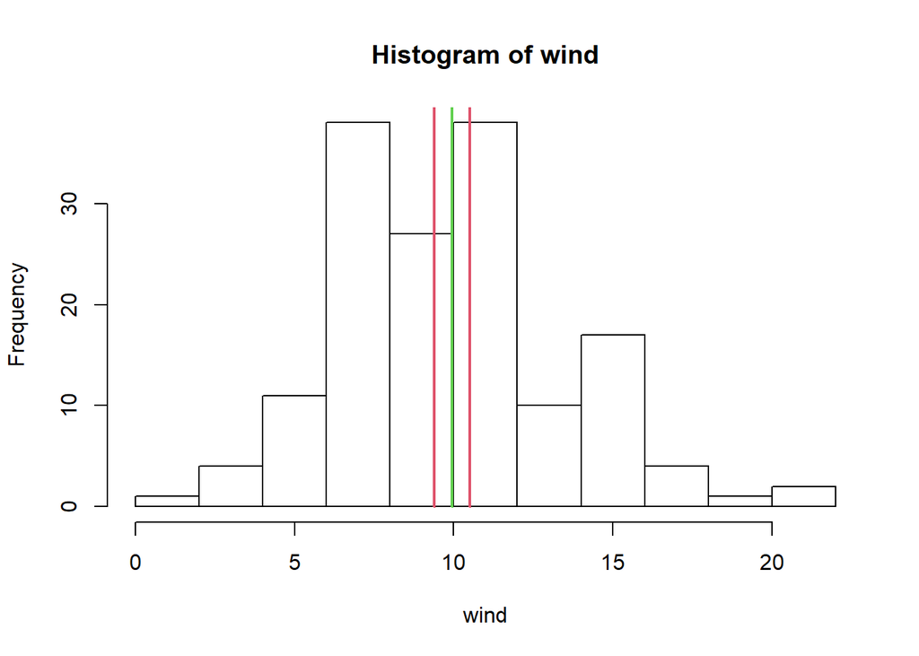

Figure 10: A histogram for the wind speed and confidence interval.

```r
hist(wind,col=0)
lines(c(LL,LL),c(0,50),col=2,lwd=2)
lines(c(UL,UL),c(0,50),col=2,lwd=2)
lines(c(M.wind,M.wind),c(0,50),col=3,lwd=2)
```

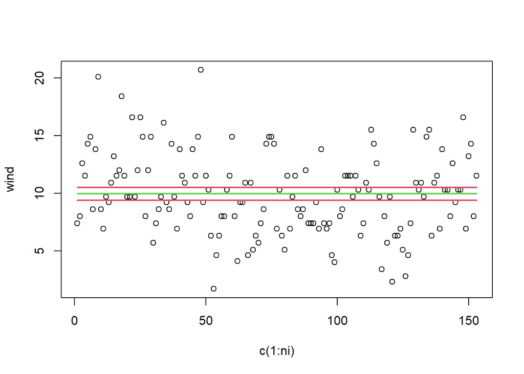

Figure 11: The daily average wind speed and a confidnce interval for the population mean.

```r
wind<-airquality$Wind
ni<-length(wind)
M.wind<-mean(wind)
plot(c(1:ni),wind)
lines(c(1,ni),c(UL,UL),col=2,lwd=2)
lines(c(1,ni),c(LL,LL),col=2,lwd=2)
lines(c(1,ni),c(M.wind,M.wind),col=3,lwd=2)
```

```r
#ggplot(airquality, aes(x = Wind, y = c(1:length(airquality$Wind)))) +
#  geom_point(position = position_jitter(width = 0.05), color = "blue") +
#  ylab("")+
#  geom_vline(xintercept = LL, color = "red", linetype = "dashed")+
#  geom_vline(xintercept = UL, color = "red", linetype = "dashed")+
#  geom_text(aes(x = LL-0.5, y = min(c(1:length(airquality$Wind))-0.5) , #label = "LL"), color = "red")+
#  geom_text(aes(x = UL+0.5, y = min(c(1:length(airquality$Wind))-0.5) , #label = "UL"), color = "red")
```

### A $95\%$ confidence interval using the R function `z.test`

The R function `z.test` requires a knowledge about the population variance. Let us assume that the population standard deviation, $\sigma$ is know and is equal to 3.52 ($\sigma=3.52$).

A general call of the function `z.test()` have the form of

```
  <tt>z.test(variable,standard deviation)</tt>
```

For the variable `wind` we have

```r
library(TeachingDemos)
wind=na.omit(airquality$Wind)
sigma=3.52
z.test(wind,sd=sigma)
```

```
##
##  One Sample z-test
##
## data:  wind
## z = 34.991, n = 153.00000, Std. Dev. = 3.52000, Std. Dev. of the sample
## mean = 0.28458, p-value < 2.2e-16
## alternative hypothesis: true mean is not equal to 0
## 95 percent confidence interval:
##   9.399759 10.515273
## sample estimates:
## mean of wind
##     9.957516
```

## Changing the confidence level

Ninety-five percent confidence intervals are the most commonly used interval estimates, but intervals with confidence levels other than $95\%$ can also be constructed. The general formula for a confidence interval (for the population mean $\mu$) with confidence level of $1-2 \times \alpha$ is given by
$$\bar{x} \pm z_{\alpha} \times SE$$
where $z_{\alpha}$ is chosen according to the confidence level. When calculating a 95% confidence level, $z_{\alpha}$ is 1.96, since, as shown in Figure 12, the area within 1.96 standard deviations of the mean captures 95% of the distribution.

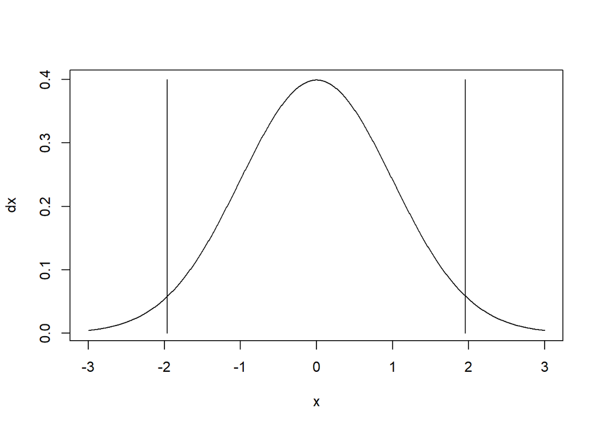

Figure 12: Quantiles for $N(0,1)$.

```r
x<-seq(from=-3,to=3,length=1000)
dx<-dnorm(x,0,1)
qx<-qnorm(0.025,0,1)
plot(x,dx,type="l")
lines(c(qx,qx),c(0,0.4))
lines(-c(qx,qx),c(0,0.4))
```

To construct a $99\%$ confidence interval, $z_{\alpha}$ must be chosen such that 99% of the normal curve is captured between $-z_{\alpha}$ and $z_{\alpha}$.In this case, $\alpha=0.005$ so $1-2 \times \alpha=0.99$ and $z_{0.005}=-2.575$ (the red line in Figure 13).

```r
qx1<-qnorm(0.005,0,1)
qx1
```

```
## [1] -2.575829
```

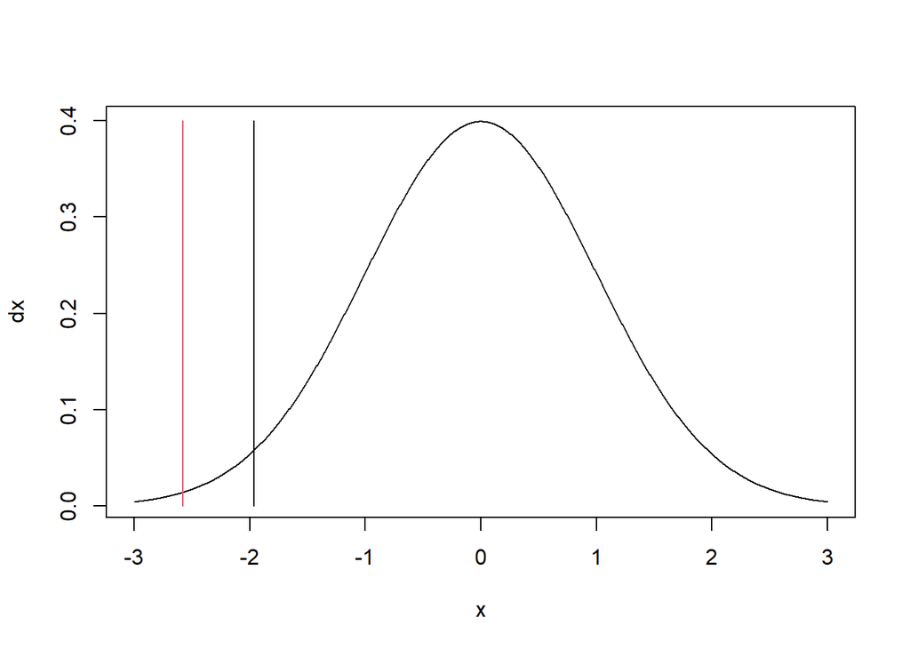

Figure 13: 0.025 abd 0.005 quantiles of $N(0,1)$.

```r
plot(x,dx,type="l")
lines(c(qx,qx),c(0,0.4))
lines(c(qx1,qx1),c(0,0.4),col=2)
```

## Interpreting confidence intervals

## Example: The NHANES dataset

The NHANES dataset consists of data from the US National Health and Nutrition Examination Study. Information about 76 variables is available for 10000 individuals included in the study. The 10000 indivuduals are considered as the population. In this section we focus on the BMI (the R object `BMI`).

```r
library(NHANES)
data(NHANES)
dim(NHANES)
```

```
## [1] 10000    76
```

### The population parameters

After removing the individuals with missing values for BMI, 9634 individuals will be considered as the **population**. For these individuals, $\mu=26.66$ and $\sigma^{2}=54.41$. These are the parameters of the population.

```r
library(NHANES)
data(NHANES)
#dim(NHANES)
#names(NHANES)
bmi<-na.omit(NHANES$BMI)
length(bmi)
```

```
## [1] 9634
```

```r
mean(bmi)
```

```
## [1] 26.66014
```

```r
var(bmi)
```

```
## [1] 54.41392
```

### Visualization

Figure 14 and 15 show the histogram and violin plot for the BMI in the population. Both figures reveal a long tail in the right side of the distribution.

```r
#ggplot(NHANES, aes(x = BMI)) +
#  geom_histogram(fill = "skyblue", color = "black")+
#  ylab("Frequency")
```

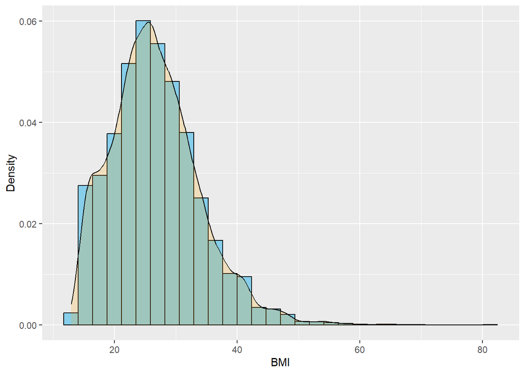

Figure 14: Histogram with density plot of BMI.

```r
ggplot(NHANES, aes(x = BMI)) +
  geom_histogram(aes(y = ..density..), fill = "skyblue", color = "black") +
  geom_density(alpha = 0.2, fill = "orange")+
  ylab("Density")
```

```r
#ggplot(NHANES, aes(x = c(1:length(NHANES$BMI)), y = BMI)) +
#  geom_point(position = position_jitter(height = 0.05), color = "blue")
# +  xlab("")
```

```r
#ggplot(NHANES, aes(x = "", y = BMI)) +
#  geom_boxplot(fill = "skyblue", color = "black") +
#  xlab("")
```

```r
#ggplot(NHANES, aes(x = "", y = BMI)) +
#  geom_boxplot(fill = "skyblue", color = "black") +
#  geom_jitter(aes(x = "", y = BMI), color = "black", size = 0.1, alpha = #0.5)+
#  xlab("")
```

```r
#ggplot(NHANES, aes(x = "", y = BMI)) +
#  geom_violin(fill = "lightblue")+
#  xlab("")
```

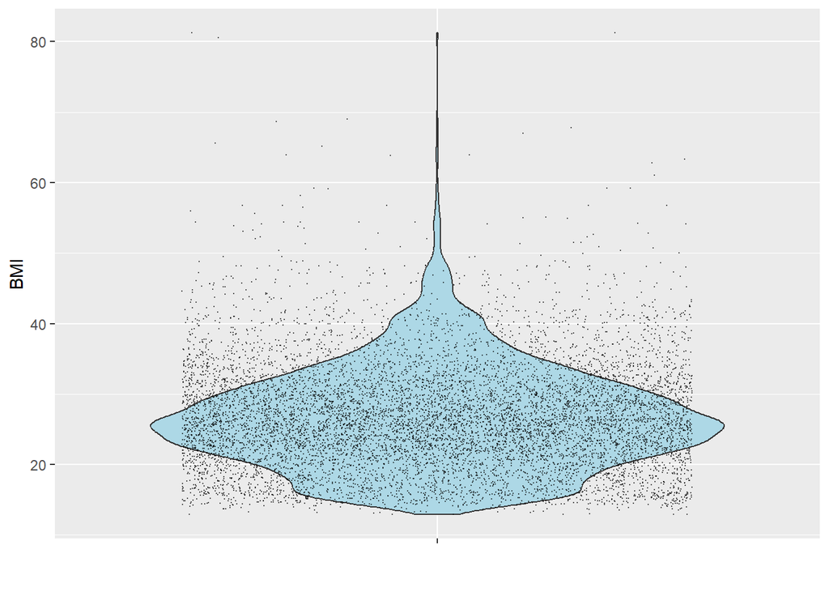

Figure 15: Violin plot of BMI.

```r
ggplot(NHANES, aes(x = "", y = BMI)) +
  geom_violin(fill = "lightblue")+
  geom_jitter(aes(x = "", y = BMI), color = "black", size = 0.1, alpha = 0.5)+
  xlab("")
```

### A random sample of size 50 from the data

```r
set.seed(123456)
x.bmi<-sample(na.omit(NHANES$BMI),size=50,replace=FALSE)
length(x.bmi)
```

```
## [1] 50
```

```r
mean(x.bmi)
```

```
## [1] 26.768
```

```r
var(x.bmi)
```

```
## [1] 87.67349
```

### Visualization

A histogram and a violin plot for the BMI sample are shown in Figure 16.

```r
hist_bmi = ggplot(data.frame(BMI = x.bmi), aes(x = BMI)) +
  geom_histogram(fill = "skyblue", color = "black")+
  ylab("Frequency")+
  ggtitle("Histogram")
```

```r
violin_bmi = ggplot(data.frame(BMI = x.bmi), aes(x = "", y = BMI)) +
  geom_violin(fill = "lightblue")+
  xlab("")+
  ggtitle("Violin plot")
```

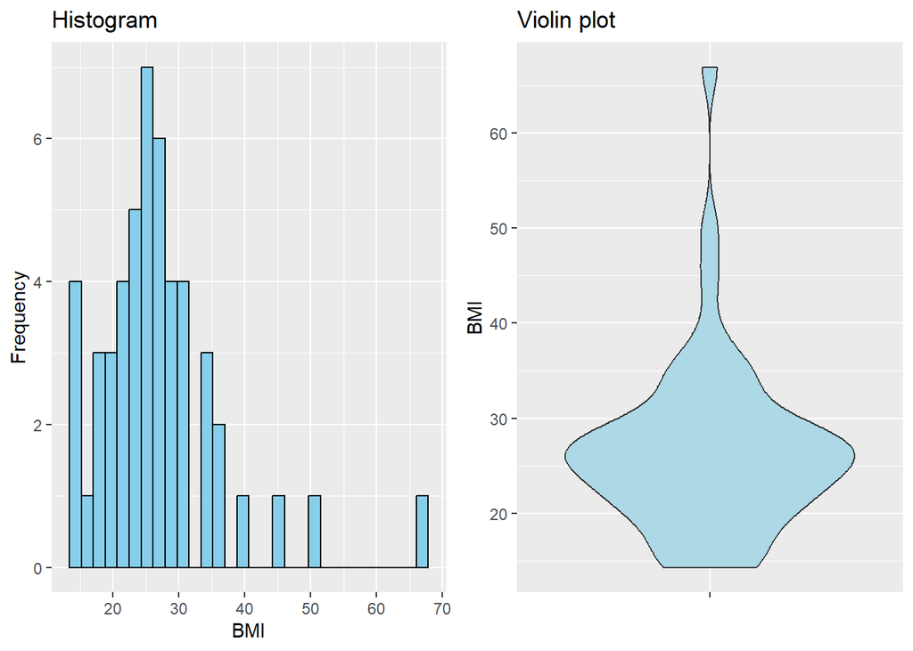

Figure 16: Histogram and violin plots of the BMI sample.

```r
grid.arrange(hist_bmi, violin_bmi, ncol = 2)
```

### A $95\%$ C.I for the mean BMI

The standard error of the sample mean is equal to

$$\frac{s}{\sqrt{n}}=\sqrt{\frac{87.67349}{50}}=1.3241.$$

```r
n<-length(x.bmi)
SD.x<-sqrt(var(x.bmi))
SE<-SD.x/sqrt(n)
SE
```

```
## [1] 1.324186
```

For a $95\%$ confidence level, $\alpha=0.025$ and $Z_{\alpha}=1.96$. The confidence interval is given by

$$\bar{x} \pm m = \bar{x} \pm 1.96 \times SE.$$
The confidence interval is given by

```r
LL<-mean(x.bmi)-1.96*SE
UL<-mean(x.bmi)+1.96*SE
c(LL,UL)
```

```
## [1] 24.17259 29.36341
```

### Visualization

The histogram of the sample with a $95\%$ confidence interval is shown in Figure 17.

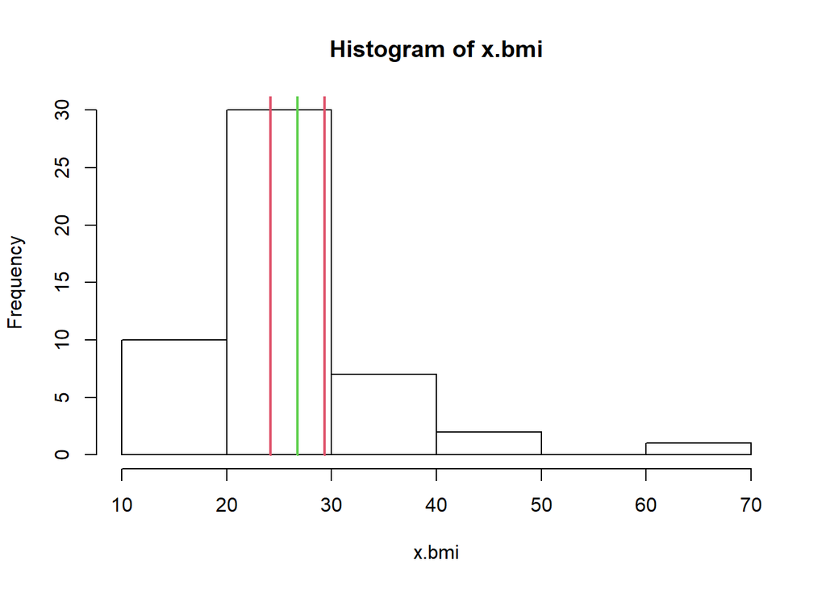

Figure 17: Histogram for the BMI with a 95% confidence interval for the population mean.

```r
M.bmi<-mean(x.bmi)
hist(x.bmi,col=0)
lines(c(LL,LL),c(0,50),col=2,lwd=2)
lines(c(UL,UL),c(0,50),col=2,lwd=2)
lines(c(M.bmi,M.bmi),c(0,50),col=3,lwd=2)
```

```r
#lines(c(26.66,26.66),c(0,50),col=4,lwd=2)
#ggplot(NHANES, aes(x = BMI, y = c(1:length(NHANES$BMI)))) +
#  geom_point(position = position_jitter(width = 0.05), color = "blue") #+
#  ylab("")+
#  geom_vline(xintercept = LL, color = "red", linetype = "dashed")+
#  geom_vline(xintercept = UL, color = "red", linetype = "dashed")+
#  geom_text(aes(x = LL-1.5, y = min(c(1:length(NHANES$BMI))-0.5) , #label = "LL"), color = "red")+
#  geom_text(aes(x = UL+1.5, y = min(c(1:length(NHANES$BMI))-0.5) , #label = "UL"), color = "red")
```

# 4. Hypothesis testing

## The Formal Approach to Hypothesis Testing

### Specifying a significance level, $\alpha$

It is important to specify how rare or unlikely an event must be in order to represent sufficient evidence against the null hypothesis. This should be done during the design phase of a study, to prevent any bias that could result from defining ’rare’ only after analyzing the results. When testing a statistical hypothesis, an investigator specifies a significance level, $\alpha$, that defines a ’rare’ event. Typically, $\alpha$ is chosen to be 0:05, though it may be larger or smaller, depending on context. An $\alpha$ level of 0:05 implies that an event occurring with probability lower than $5\%$ will be considered sufficient evidence against $H_{0}$.

### Calculating the test statistic

Calculating the test statistic $t$ is analogous to standardizing observations with Z-scores. The test statistic quantifies the number of standard deviations between the sample mean $\bar{x}$ and the population mean $\mu$. If the population standard deviation is known the test statistic given by

$$t=\frac{\bar{x}-\mu_{0}}{\sigma/\sqrt{n}}.$$

If $\sigma$ is unknown, we use the parameter estimate from the sample, $s$,

$$t=\frac{\bar{x}-\mu_{0}}{s/ \sqrt{n}}.$$

### Calculating the $p$-value

The p-value is the probability of observing a sample mean as or more extreme than the observed value, under the assumption that the null hypothesis is true. In samples of size 40 or more, the t-statistic will have a standard normal distribution $N(0,1)$ unless the data are strongly skewed or extreme outliers are present.

- For two-sided tests, with $H_{A} : \mu =\ne \mu_{0}$, the p-value is the sum of the area of the two tails defined by the t-statistic:
  $$2 \times P(Z > |t|) .$$
- For one-sided tests with $H_{A}: \mu > \mu_{0}$ , the $p$-value is given by $P (Z > t)$. For $H_{A}:\mu < \mu_{0}$ , the $p$-value is the area to the left of the t-statistic, $P(Z \le t)$.

## Example 1: wind speed in New York 1973

### The sample and point estimators

```r
wind<-airquality$Wind
M.wind<-mean(wind)
SD.wind<-sqrt(var(wind))
M.wind
```

```
## [1] 9.957516
```

```r
SD.wind
```

```
## [1] 3.523001
```

```r
#hist(wind)
```

### Hypothesis testing

We wish to test the null hypothesis versus a two sided alternative, that is

$$H_{0}:\mu=9\;\;\mbox{Vs.}\;\; H_{1}:\mu \ne 9$$

### Test statistic

$$t=\frac{\bar{x}-\mu_{0}}{s/\sqrt{n}}=\frac{9.957-9}{3.523 / \sqrt{153}}=3.3619$$

### $p$-value

The $p$-value is equal to $(1-P(Z \le |3.3619|)) \times 2=2 \times 0.000387=0.000774<0.05$ and therefore the null hypothesis is rejected.

```r
1-pnorm(3.3619,0,1)
```

```
## [1] 0.0003870408
```

```r
2*(1-pnorm(3.3619,0,1))
```

```
## [1] 0.0007740815
```

Note that the $p$-value is equal to tiwce the area above the test statistic 3.3691 in Figure 18.

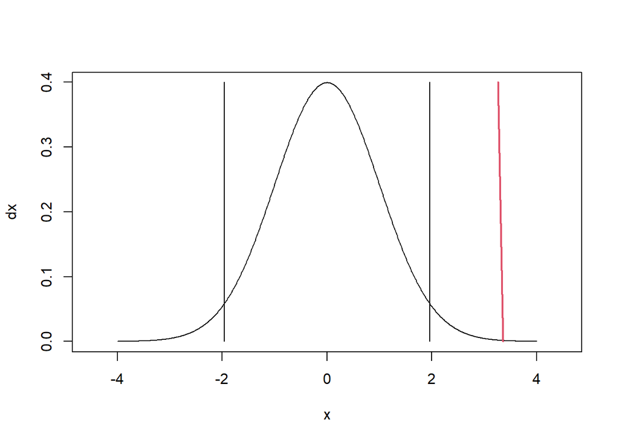

Figure 18: Illustraion of the p-value.

```r
x<-seq(from=-4,to=4,length=1000)
dx<-dnorm(x,0,1)
qx<-qnorm(0.025,0,1)
plot(x,dx,type="l",xlim=c(-4.5,4.5))
lines(c(qx,qx),c(0,0.4))
lines(-c(qx,qx),c(0,0.4))
lines(c(3.3619,3.2619),c(0,0.4),col=2,lwd=2)
```

### Using the R function `z.test`

We assume that in the population $\sigma=s=3.523$ and produce the follwoing results using the function `z.test`.

```r
wind<-airquality$Wind
M.wind<-mean(wind)
SD.wind<-sqrt(var(wind))
#SD.wind
z.test(wind,SD.wind,mu=9)
```

```
##
##  One Sample z-test
##
## data:  wind
## z = 3.3619, n = 153.00000, Std. Dev. = 3.52300, Std. Dev. of the sample
## mean = 0.28482, p-value = 0.0007742
## alternative hypothesis: true mean is not equal to 9
## 95 percent confidence interval:
##   9.399284 10.515749
## sample estimates:
## mean of wind
##     9.957516
```

## Example 2: The NHANES data set analysis of the number of sleep hours per night

### The population

In this section, the variable of interest is the number of sleeping hours per night (the variable `SleepHrsNight`). Information about the number of sleeping hours per night is available for 7755 individuals (i.e., the population). The population mean and variance are $\mu=6.927$ and $\sigma^{2}=1.813$, respectively.

```r
library(NHANES)
data(NHANES)
#dim(NHANES)
sleep<-na.omit(NHANES$SleepHrsNight)
length(sleep)
```

```
## [1] 7755
```

```r
mean(sleep)
```

```
## [1] 6.927531
```

```r
var(sleep)
```

```
## [1] 1.81368
```

### Visualization

Figure 19 and 20 show the histogram and boxplot of the number of sleeping hours in the population and reveal a discrete distribution as expected. Note that the number of sleeping hours per night is a count variable.

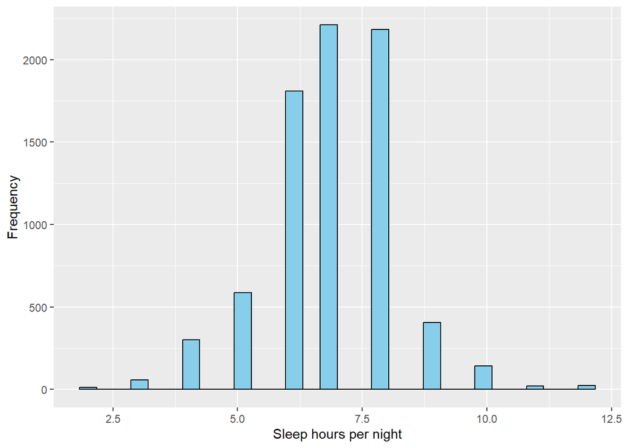

Figure 19: Histogram of sleep hours per night.

```r
ggplot(NHANES, aes(x = SleepHrsNight)) +
  geom_histogram(fill = "skyblue", color = "black")+
  ylab("Frequency")+
  xlab("Sleep hours per night")
```

```r
#ggplot(NHANES, aes(x = SleepHrsNight)) +
#  geom_histogram(aes(y = ..density..), fill = "skyblue", color = #"black") +
#  geom_density(alpha = 0.2, fill = "orange")+
#  ylab("Density")+
#  xlab("Sleep hours per night")
```

```r
#ggplot(NHANES, aes(x = c(1:length(NHANES$SleepHrsNight)), y = #SleepHrsNight)) +
#  geom_point(position = position_jitter(height = 0.05), color = "blue") #+
#  xlab("")+
#  ylab("Sleep hours per night")
```

```r
#ggplot(NHANES, aes(x = "", y = SleepHrsNight)) +
#  geom_boxplot(fill = "skyblue", color = "black")+
#  ylab("Sleep hours per night")+
#  xlab("")
```

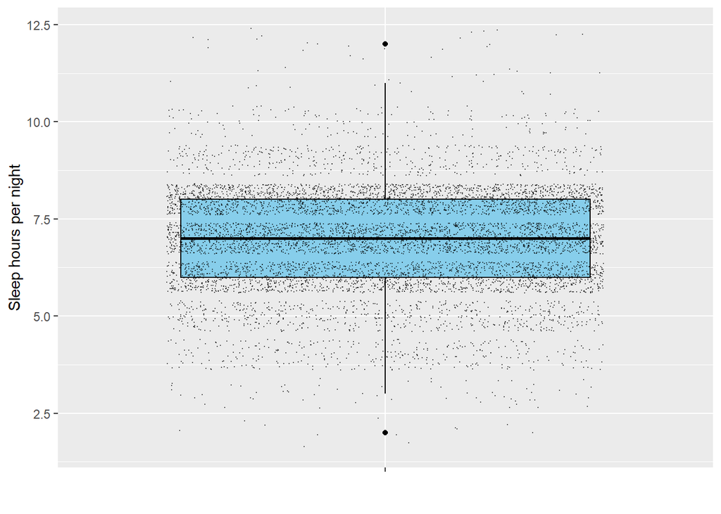

Figure 20: Box plot of sleep hours per night.

```r
ggplot(NHANES, aes(x = "", y = SleepHrsNight)) +
  geom_boxplot(fill = "skyblue", color = "black")+
  geom_jitter(aes(x = "", y = SleepHrsNight), color = "black", size = 0.1, alpha = 0.5)+
  ylab("Sleep hours per night")+
  xlab("")
```

```r
#ggplot(NHANES, aes(x = "", y = SleepHrsNight)) +
#  geom_violin(fill = "lightblue")+
#  xlab("")+
#  ylab("Sleep hours per night")
```

```r
#ggplot(NHANES, aes(x = "", y = SleepHrsNight)) +
#  geom_violin(fill = "lightblue")+
#  geom_jitter(aes(x = "", y = SleepHrsNight), color = "black", size = #0.1, alpha = 0.5)+
#  xlab("")+
#  ylab("Sleep hours per night")
```

### A random sample of size 150 from the population

We draw a sample of 150 indivuduals from the population ($n=150$). The point estimates for the sample are $\bar{x}=6.8466$ and $\sigma^{2}=1.8622$.

```r
set.seed(456789)
x.sleep<-sample(na.omit(NHANES$SleepHrsNight),size=150,replace=FALSE)
length(x.sleep)
```

```
## [1] 150
```

```r
mean(x.sleep)
```

```
## [1] 6.846667
```

```r
var(x.sleep)
```

```
## [1] 1.862237
```

#### Visualization

Figure 21 shows the histogram (left panel) and boxplot (right panel) of the sample.

```r
hist_sleep = ggplot(data.frame(SleepHrsNight = x.sleep), aes(x = SleepHrsNight)) +
  geom_histogram(fill = "skyblue", color = "black")+
  ylab("Frequency")+
  xlab("Sleep hours per night")+
  ggtitle("Histogram")
```

```r
box_sleep = ggplot(data.frame(SleepHrsNight = x.sleep), aes(x = "", y = SleepHrsNight)) +
  geom_boxplot(fill = "lightblue")+
  xlab("")+
  ylab("Sleep hours per night")+
  ggtitle("Box plot")
```

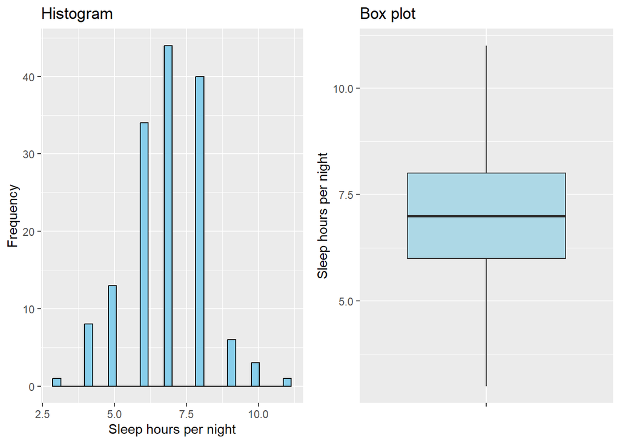

Figure 21: Histogram and box plot of sleep hours per night in the sample.

```r
grid.arrange(hist_sleep, box_sleep, ncol = 2)
```

#### A $95\%$ C.I for the mean sleep hours per night

The sample standard deveation and the standard error of the sample mean are equal to 1.3646 and 0.1114, respectivly.

```r
n<-length(x.sleep)
SD.x<-sqrt(var(x.sleep))
SD.x
```

```
## [1] 1.364638
```

```r
SE<-SD.x/sqrt(n)
SE
```

```
## [1] 0.1114222
```

For the sample, the error margin for a $95\%$ confidence interval is $m=1.96 \times SE=1.96 \times 0.1114$ and the confidence interval is given by
$$\bar{x} \pm m=6.8466 \pm 0.2183 = (6.628279,7.065054).$$

```r
LL<-mean(x.sleep)-1.96*SE
UL<-mean(x.sleep)+1.96*SE
c(LL,UL)
```

```
## [1] 6.628279 7.065054
```

#### Visualization

```r
#ggplot(NHANES, aes(x = SleepHrsNight, y = #c(1:length(NHANES$SleepHrsNight)))) +
#  geom_point(position = position_jitter(width = 0.05), color = "blue") #+
#  ylab("")+
#  xlab("Sleep hours per night")+
#  geom_vline(xintercept = LL, color = "red", linetype = "dashed")+
#  geom_vline(xintercept = UL, color = "red", linetype = "dashed")+
#  geom_text(aes(x = LL-0.5, y = #min(c(1:length(NHANES$SleepHrsNight))-0.5) , label = "LL"), color = #"red")+
#  geom_text(aes(x = UL+0.5, y = #min(c(1:length(NHANES$SleepHrsNight))-0.5) , label = "UL"), color = #"red")
```

#### Hypothesis testing

We wish to test the null hypothesis $\mu=7$ aginst a one sided alternative $H_{1}:\mu <7$. This can be done using the argument `alternative = ‘less’` in the function `z.test`. Note that we assume that in the population, $\sigma=1.3646$. As can be seen in the panel below, for the sample, the mean number of sleeping hours is equal to $\bar{x}=6.8466$ and the test statistic is equal to $-1.3761$. The $p$-=0.08439 > 0.05$. We cannot reject the null hypothesis and conclude that $\mu=7$.

```r
mean(x.sleep)
```

```
## [1] 6.846667
```

```r
sqrt(var(x.sleep))
```

```
## [1] 1.364638
```

```r
z.test(x.sleep,mu=7, 1.364638, alternative = 'less')
```

```
##
##  One Sample z-test
##
## data:  x.sleep
## z = -1.3761, n = 150.00000, Std. Dev. = 1.36464, Std. Dev. of the
## sample mean = 0.11142, p-value = 0.08439
## alternative hypothesis: true mean is less than 7
## 95 percent confidence interval:
##     -Inf 7.02994
## sample estimates:
## mean of x.sleep
##        6.846667
```

# 5 Hypothesis testing and confidence intervals

## Two sided alternatives and confidence intervals

- *Hypothesis Test*. For a two-sided test, $\bar{x}$ needs to be at l east $m$ units away from $\mu_{0}$ in either direction to be considered extreme. The t-points marking off the  
  rejection region are equal to the $z_\alpha$ value used in the confidence interval, with the positive andnegative t-points accounting for the $\pm$ structure in the confidence interval.
- *Confidence Interval*. The plausible range of values for $\mu_{0}$ around $\bar{x}$ is defined as $(\bar{x} - m; \bar{x} +m)$. If $\mu_{0}$ is plausible, it can at most be m units away in either direction from $\bar{x}$. If the interval does not contain $\mu_{0}$, then $\mu_{0}$ is implausible according to and there is sufficient evidence to reject $H_{0}$.

## Example: The NHANES dataset - analysis of the total cholestrol level

### Population

In this section we focus on the total cholesterol level (the variable `TotChol`). After omitting all individuals with missing values, 8474 individuals are included in the analysis. The population parameters are equal to $\mu=4.879$ and $\sigma=1.075$.

```r
library(NHANES)
data(NHANES)
dim(NHANES)
```

```
## [1] 10000    76
```

```r
#names(NHANES)
totchol<-na.omit(NHANES$TotChol)
length(totchol)
```

```
## [1] 8474
```

```r
mean(totchol)
```

```
## [1] 4.87922
```

```r
sqrt(var(totchol))
```

```
## [1] 1.075583
```

### Visualization

Figure 22, 23 and 24 present the data and indicate that the population distribution has a long right tail.

```r
#ggplot(NHANES, aes(x = TotChol)) +
#  geom_histogram(fill = "skyblue", color = "black")+
#  ylab("Frequency")+
#  xlab("The total cholestrol level")
```

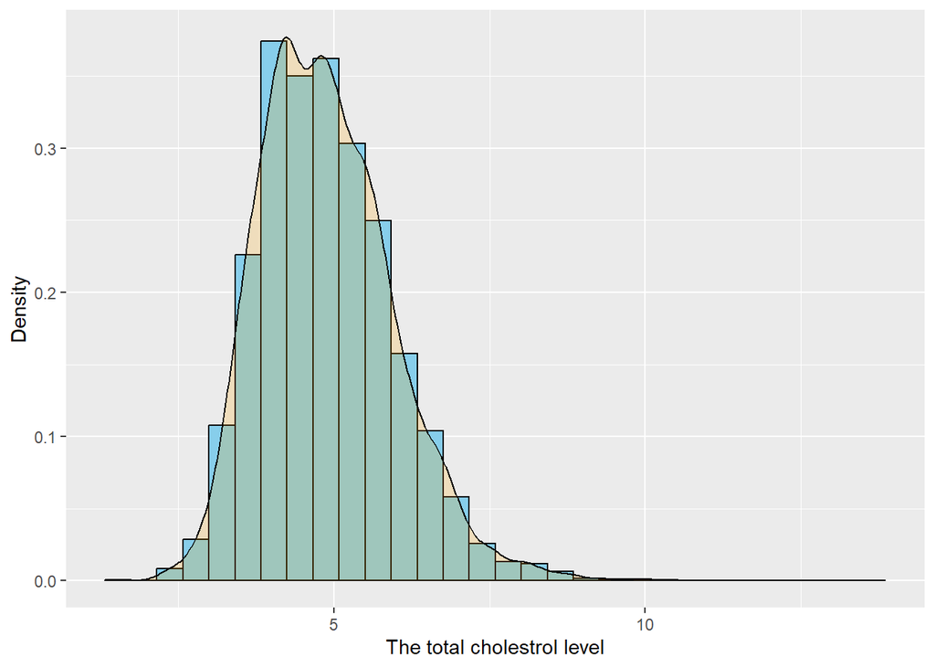

Figure 22: Histogram with density plot of the total cholestrol level.

```r
ggplot(NHANES, aes(x = TotChol)) +
  geom_histogram(aes(y = ..density..), fill = "skyblue", color = "black") +
  geom_density(alpha = 0.2, fill = "orange")+
  ylab("Density")+
  xlab("The total cholestrol level")
```

```r
#ggplot(NHANES, aes(x = c(1:length(NHANES$TotChol)), y = TotChol)) +
#  geom_point(position = position_jitter(height = 0.05), color = "blue") #+
#  xlab("")+
#  ylab("The total cholestrol level")
```

```r
#ggplot(NHANES, aes(x = "", y = TotChol)) +
#  geom_boxplot(fill = "skyblue", color = "black")+
#  ylab("The total cholestrol level")+
#  xlab("")
```

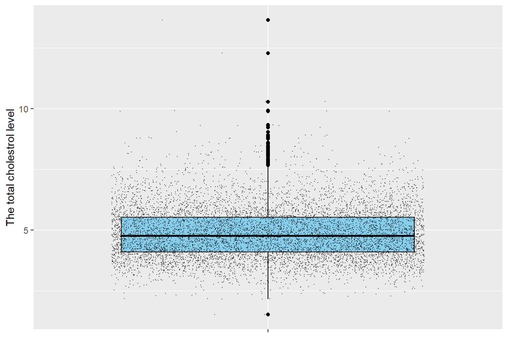

Figure 23: Box plot of the total cholestrol level.

```r
ggplot(NHANES, aes(x = "", y = TotChol)) +
  geom_boxplot(fill = "skyblue", color = "black")+
  ylab("The total cholestrol level")+
  geom_jitter(aes(x = "", y = TotChol), color = "black", size = 0.1, alpha = 0.5)+
  xlab("")
```

```r
#ggplot(NHANES, aes(x = "", y = TotChol)) +
#  geom_violin(fill = "lightblue")+
#  xlab("")+
#  ylab("The total cholestrol level")
```

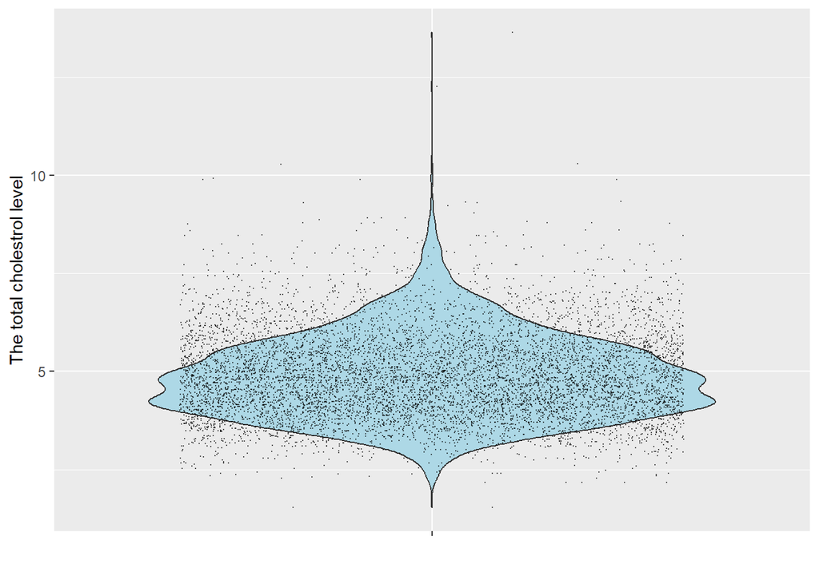

Figure 24: Violin plot of the total cholestrol level.

```r
ggplot(NHANES, aes(x = "", y = TotChol)) +
  geom_violin(fill = "lightblue")+
  geom_jitter(aes(x = "", y = TotChol), color = "black", size = 0.1, alpha = 0.5)+
  xlab("")+
  ylab("The total cholestrol level")
```

### Sample of size 100 from the population

For a sample of 100 individuals, shown in Figure 25, $\bar{x}=5.0041$ and $s=1.20723$. This implies that the standard error of the sample means is equal to
$$\frac{1.20723}{10}=0.120723.$$
.

```r
set.seed(101112)
x.totchol<-sample(na.omit(NHANES$TotChol),size=100,replace=FALSE)
length(x.totchol)
```

```
## [1] 100
```

```r
mean(x.totchol)
```

```
## [1] 5.0041
```

```r
sqrt(var(x.totchol))
```

```
## [1] 1.20723
```

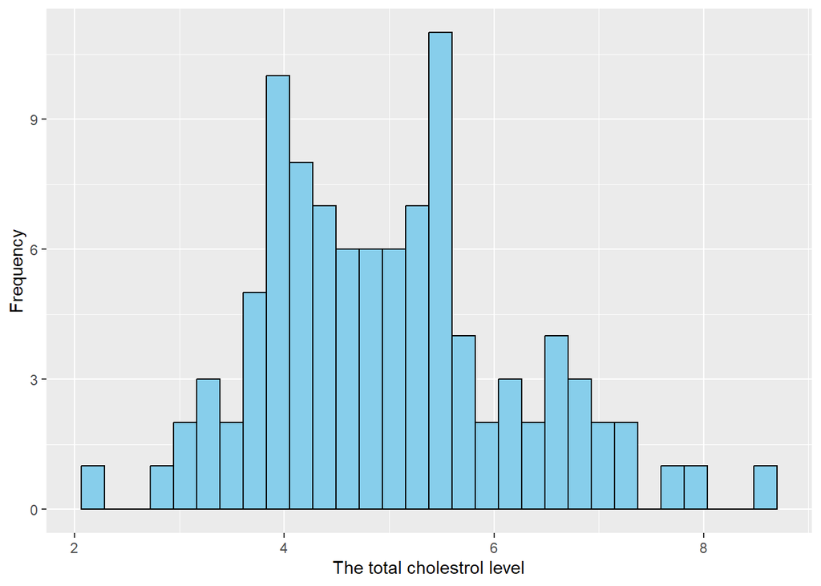

Figure 25: Histogram of the total cholestrol level in the sample.

```r
ggplot(data.frame(TotChol = x.totchol), aes(x = TotChol)) +
  geom_histogram(fill = "skyblue", color = "black")+
  ylab("Frequency")+
  xlab("The total cholestrol level")
```

### Visualization

The distribution of the total cholesterol in the same is shown in Figure 26.

```r
box_totchol = ggplot(data.frame(TotChol = x.totchol), aes(x = "", y = TotChol)) +
  geom_boxplot(fill = "lightblue")+
  geom_jitter(aes(x = "", y = TotChol), color = "black", size = 0.5, alpha = 0.5)+
  xlab("")+
  ylab("The total cholestrol level")+
  ggtitle("Box plot")
```

```r
violin_totchol = ggplot(data.frame(TotChol = x.totchol), aes(x = "", y = TotChol)) +
  geom_violin(fill = "lightblue")+
  geom_jitter(aes(x = "", y = TotChol), color = "black", size = 0.5, alpha = 0.5)+
  xlab("")+
  ylab("The total cholestrol level")+
  ggtitle("Violin plot")
```

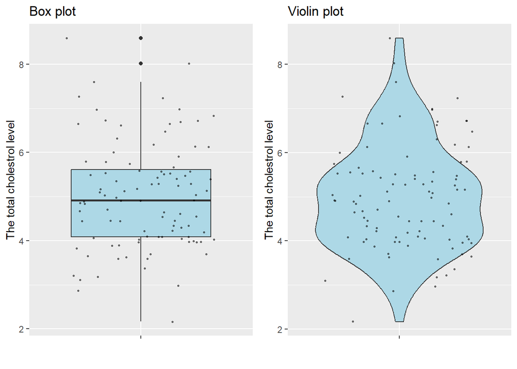

Figure 26: Box plot and violin plot of the total cholestrol level in the sample.

```r
grid.arrange(box_totchol, violin_totchol, ncol = 2)
```

### A $95\%$ confidence intervals for the mean cholestrol level in the population

A $95\%$ confidence interval ($\alpha=0.025$, $(1-2\alpha) \times 100 =95$) for the population mean is given by

$$5.0041 \pm 1.96 \times 0.120723=(4.767487,5.240713).$$

```r
z.test(x.totchol,mu=5.1, 1.20723)
```

```
##
##  One Sample z-test
##
## data:  x.totchol
## z = -0.79438, n = 100.00000, Std. Dev. = 1.20723, Std. Dev. of the
## sample mean = 0.12072, p-value = 0.427
## alternative hypothesis: true mean is not equal to 5.1
## 95 percent confidence interval:
##  4.767487 5.240713
## sample estimates:
## mean of x.totchol
##            5.0041
```

Figure 27 shows a histogram of the data with a $95\%$ confidence interval (red lines), the sample mean (blue line) and the value of $\mu_{0}$ (green line).

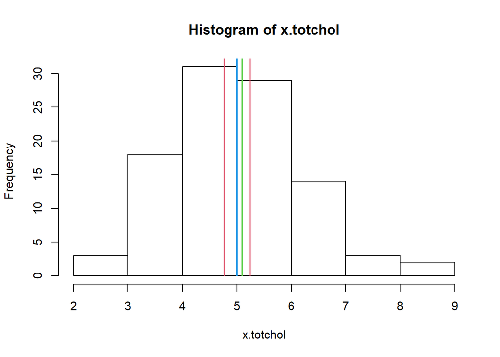

Figure 27: Histogram of the total cholesterolt and a 95% confidence interval for the population mean.

```r
hist(x.totchol,col=0)
LL<-4.767487
UL<-5.240713
mu0<-5.1
xbar<-5.0041
lines(c(LL,LL),c(0,50),col=2,lwd=2)
lines(c(UL,UL),c(0,50),col=2,lwd=2)
lines(c(mu0,mu0),c(0,50),col=3,lwd=2)
lines(c(xbar,xbar),c(0,50),col=4,lwd=2)
```

# 6 Decision error (Type I and Type II error)

## Type I and Type II errors

Hypothesis tests can potentially result in incorrect decisions, such as rejecting the null hypothesis when the null is actually true or not rejecting the null hypothesis when the alternative is correct.

- **Type I error**: rejecting the null hypothesis when the null is true.
- **Type II error**: failing to reject the null hypothesis when the alternative is true.

## Significance level and power

The probability of making a Type I error is the same as the significance level $\alpha$, that is

$$\alpha=P(\mbox{reject}\;H_{0} \; \mbox{when}\;H_{0}\; \mbox{is true}),$$

since $\alpha$ determines the cutoff point for rejecting the null hypothesis. For example, if $\alpha$ is chosen to be 0.05, then there is a $5\%$ chance of incorrectly rejecting $H_{0}$.

The probability of making a Type II error is equal to $\beta$,
$$\beta=P(\mbox{do not reject}\; H_{0}\; \mbox{when}\;H_{A}\; \mbox{is true}),$$
The power of the test, $1-\beta$ is the probability to make a correct decision when $H_{A}$ is correct,

$$1-\beta=P(\mbox{reject}\; H_{0}\; \mbox{when}\;H_{A}\; \mbox{is true}).$$

The rate of Type I error can be reduced by lowering $\alpha$ (e.g., to 0.01 instead of 0.05); doing so requires an observation to be more extreme to qualify as sufficient evidence against the null hypothesis. However, this inevitably raises the rate of Type II errors (and lowering the power $1-\beta$), since the test will now have a higher chance of failing to reject the null hypothesis when the alternative is true.